# Informe diagnóstico comunitario

Mauricio Blanco Gamboa

8/9/2020

# Información general

Los datos aqui utilizados corresponden a una encuesta telefónica realizada a clientes de la ASADA Bijagua, del distrito de Bijagua, cantón de Upala, por el TC-550 de la Universidad de Costa Rica, entre el 2 de agosto de 2020 y 9 de agosto de 2020. Se obtuvieron un total de 121 respuestas de aproximadamente 1900 clientes actuales de la institución.

Bajo esta cantidad de información, se estima un margen de error de 8.7 puntos, con un 95% de confianza en el muestreo realizado.

La data fue descargada directamente de Google Sheets, por lo que se procedió a adaptarla a un formato accesible para R.

## Trabajo de formato de la data.

En primer lugar, fue necesario procesar la información de los barrios, pues al ser una pregunta abierta, las respuestas tenían diferencia en cuanto a su formato. Se agruparon todas las opciones que no se repetían ni una sola vez en una sola opción de “otros”.

Ahora que la información de barrios está almacenada factores, se procede a su graficación.

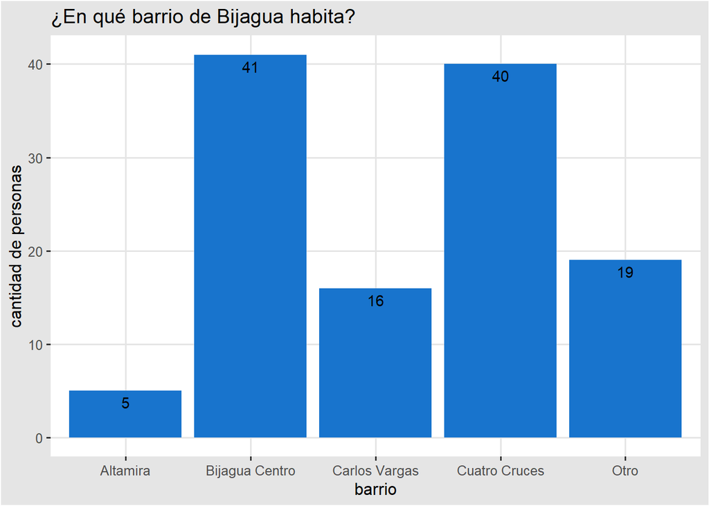

De igual forma, en cuanto a características demográficas de la muestra, se graficará a continuación la información relativa a la edad y género de la muestra.

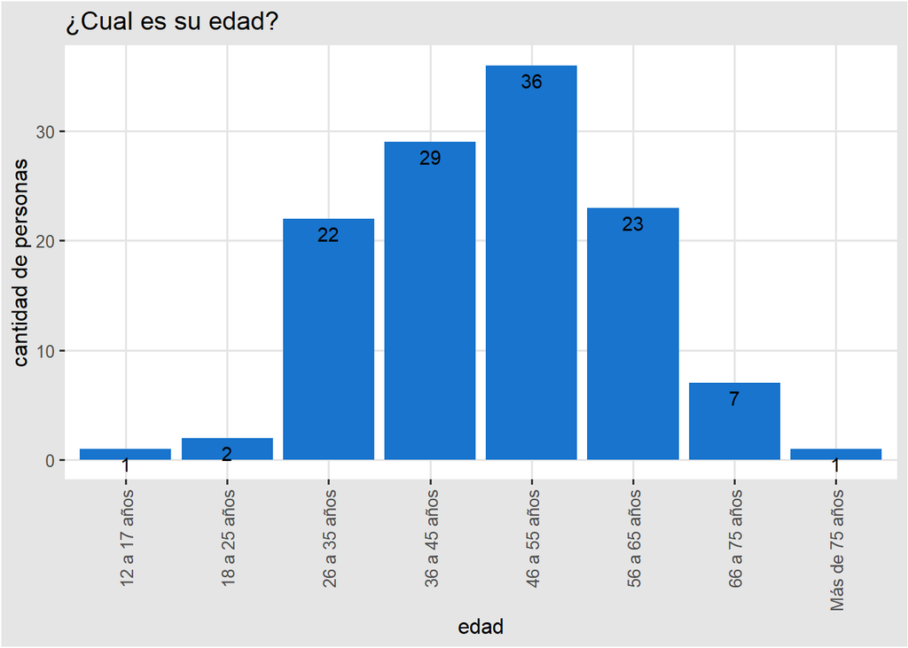

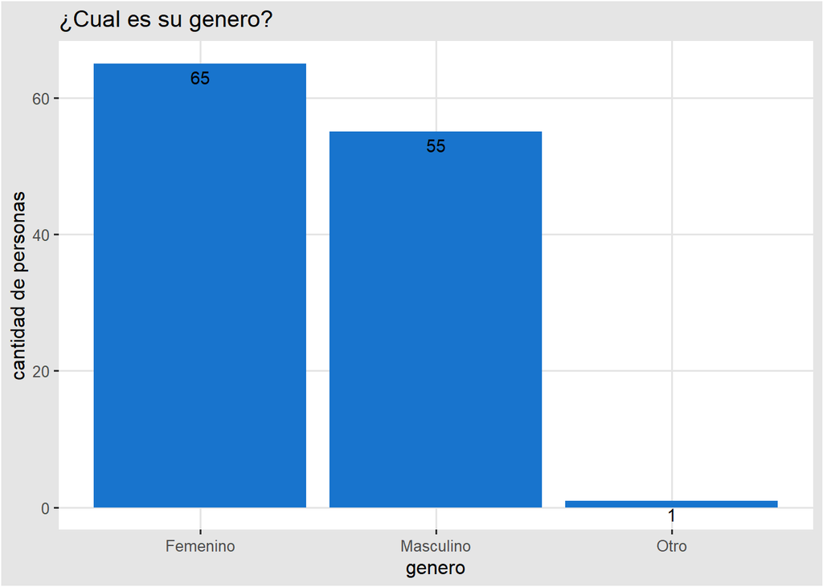

# Involucramiento comunal

Asimismo, se desprende de la información de la encuesta, la participación de personas en organizaciones comunales tales como la Asociación de Desarrollo de Bijagua, el Comité de Seguridad Cantonal, entre otros.

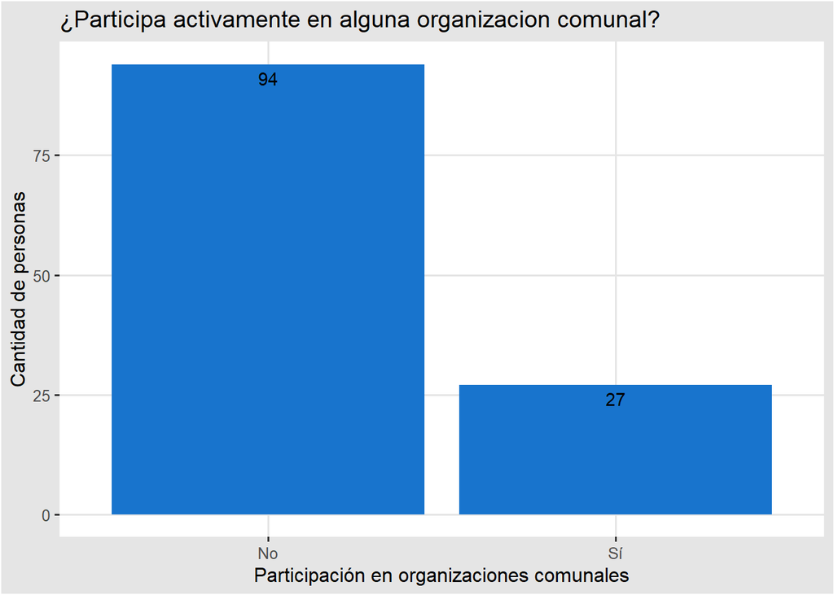

Se ve que la mayor parte de la muestra no trabaja activamente en un espacio comunal, pero sigue siendo un número significativo, que puede encontrarse por encima del promedio nacional.

# Medios de recepción de información

Para graficar los medios de recepción de información de la población, sí fue necesario realizar unas modificaciones en la data. Esto en el entendido que Google Drive lo exporta como varias opciones, separadas por una coma, dentro de una misma casilla de Excel.

Se procede a su graficación, en función del porcentaje de respuestas (al poder seleccionarse más de una y ser relevante cuánto porcentaje de la muestra seleccionó cada opción) y estableciendo los límites en cero y cien por ciento.

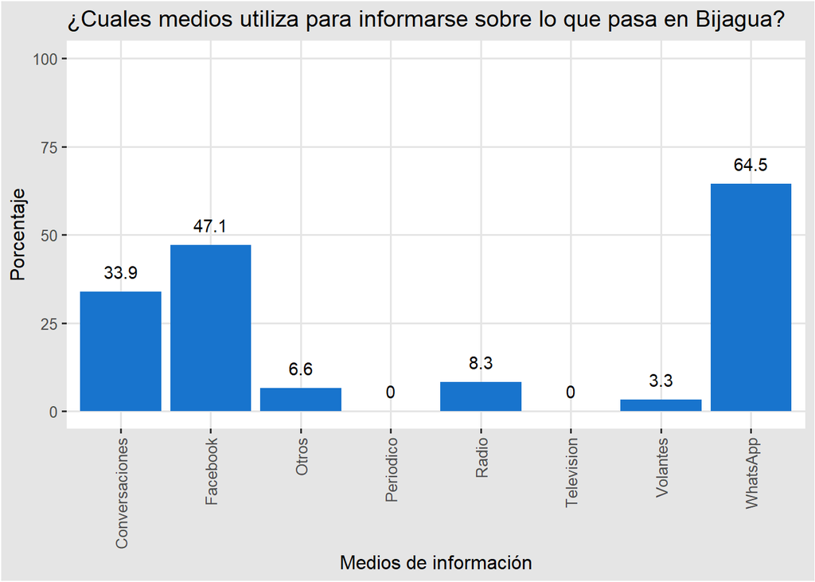

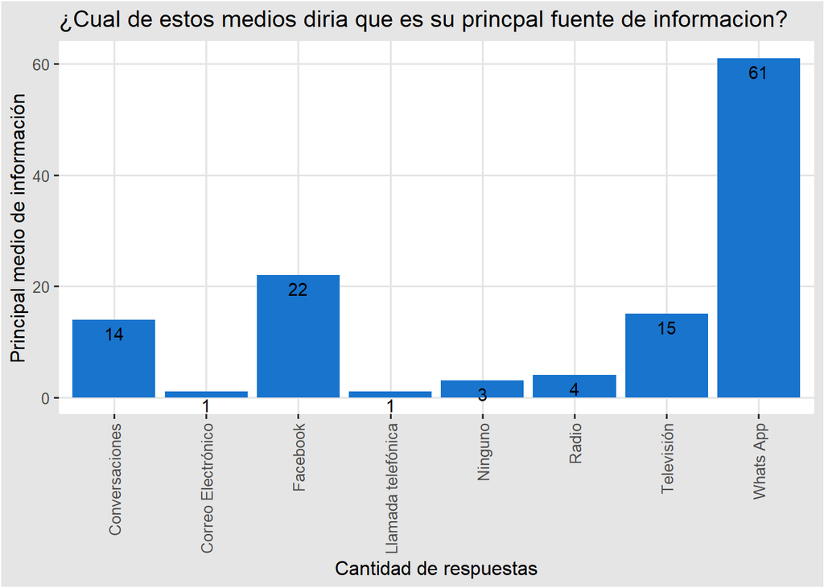

Es muy importante que Whats App salga con un porcentaje tan alto en estas dos preguntas, pues evidencia una dinámica comunicacional muy importante de la comunidad y es que los chats de Whats App son el principal medio de comunicación para recepción y difusión de información. Asímismo, Facebook tiene un porcentaje alto de impacto.

Estas dos redes cuentan con la ventaja de ser accesibles tanto para la ASADA, como para el TC-550, por lo que es posible dirigir esfuerzos a través de estos medios (asunto que sería más difícil, por ejemplo, en la televisión).

# Reconocimiento de instituciones públicas que trabajan en Bijagua.

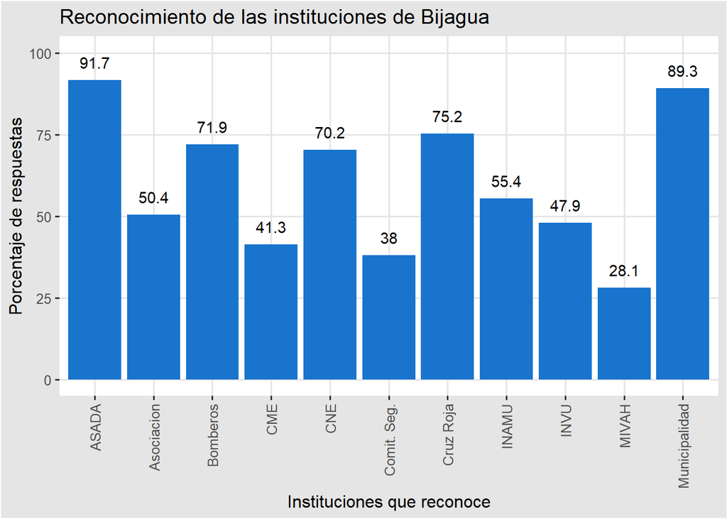

Las respuestas anteriores invocan un conocimiento muy general de cada institución u organización, por lo que es probable que los porcentajes estén sobreestimados si en cuanto a un conocimiento profundo se refiere. Más bien, es importante revisar las tendencias, cuáles instituciones tienen más reconocimiento y cuáles no.

La ASADA, evidentemente, tiene un porcentaje muy alto de reconocimiento en la comunidad, esto representa una fortaleza de la organización en su vínculo comunitario. Asímismo, otras instituciones rindieron buenos resultados, como la Municipalidad.

En cambio, se resalta el Comité Municipal de Emergencias como una de las organizaciones con más posibilidades de mejora en los aspectos comunicativos. Es posible que esta sea una eventual área de apoyo para la labor que realiza el TC-550 de la Universidad de Costa Rica.

En cuanto a los materiales que prefiere recibir la comunidad se obtuvo lo siguiente:

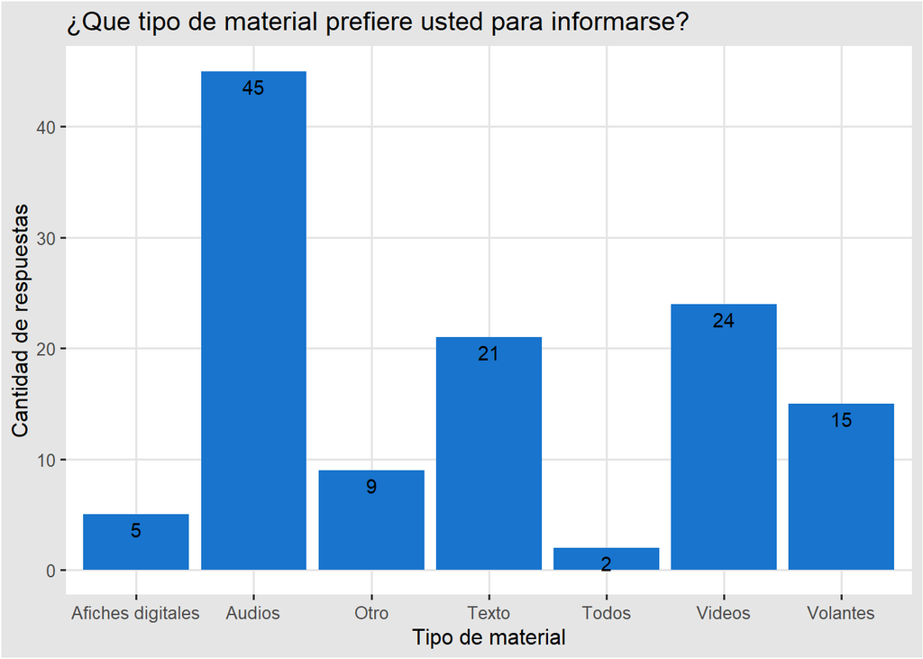

Los audios tienen un nivel importante de preferencia, por lo que dirigir esfuerzos a través de productos como podcasts, o simples audios de Whats App, puede tener un alcance muy amplio en las comunidades del distrito Bijagua. Asímismo, para temas en los que se pueda invertir más en producción, el contenido audiovisual representa una oportunidad para mejorar la comunicación tanto de la ASADA como de las instituciones vinculadas a la gestión de riesgo.

La siguiente pregunta se graficará mediante el uso de un “WordCloud”, y es la siguiente:

¿Cuál cree usted que sea la forma más eficiente para difundir información en la comunidad?

```
##              word freq
## whatsapp whatsapp   33
## redes       redes   17
## por           por   17
## sociales sociales   16
## facebook facebook   16
## grupos     grupos   14
## medio       medio   14
## que           que   14
## para         para    9
## más           más    9
```

[interactive chart not shown]

Nuevamente, WhatsApp (y Facebook en segundo lugar) se posiciona como un medio ideal para la difusión de contenido comunal en el distrito de Bijagua. En adición a esto, se puede observar que “redes sociales”, “grupos” y “digitales” son palabras resaltadas en esta visualización.

# Preguntas de reconocimiento sobre la ASADA

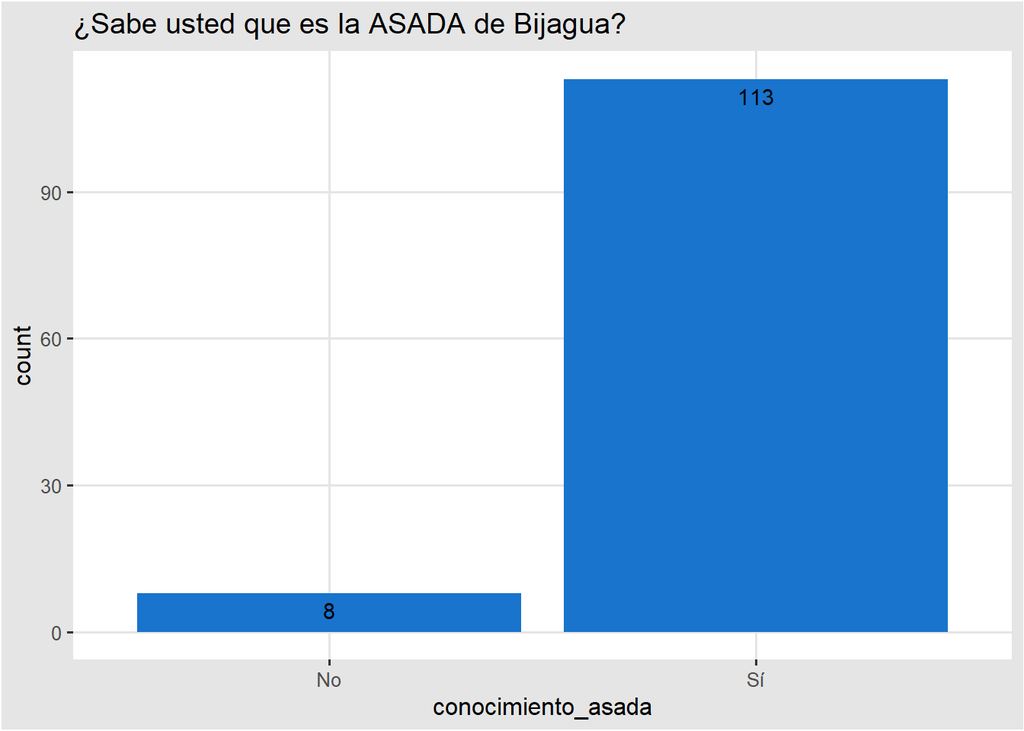

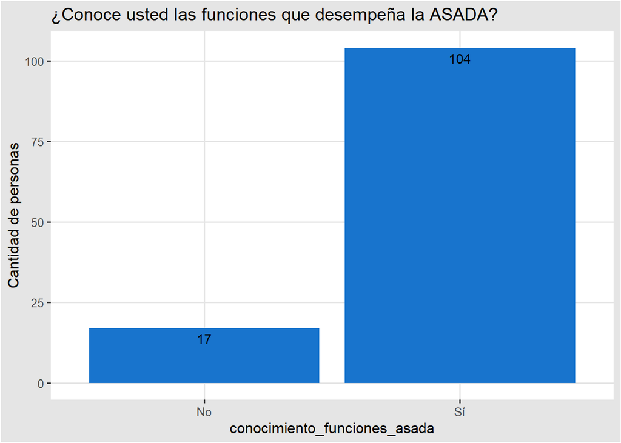

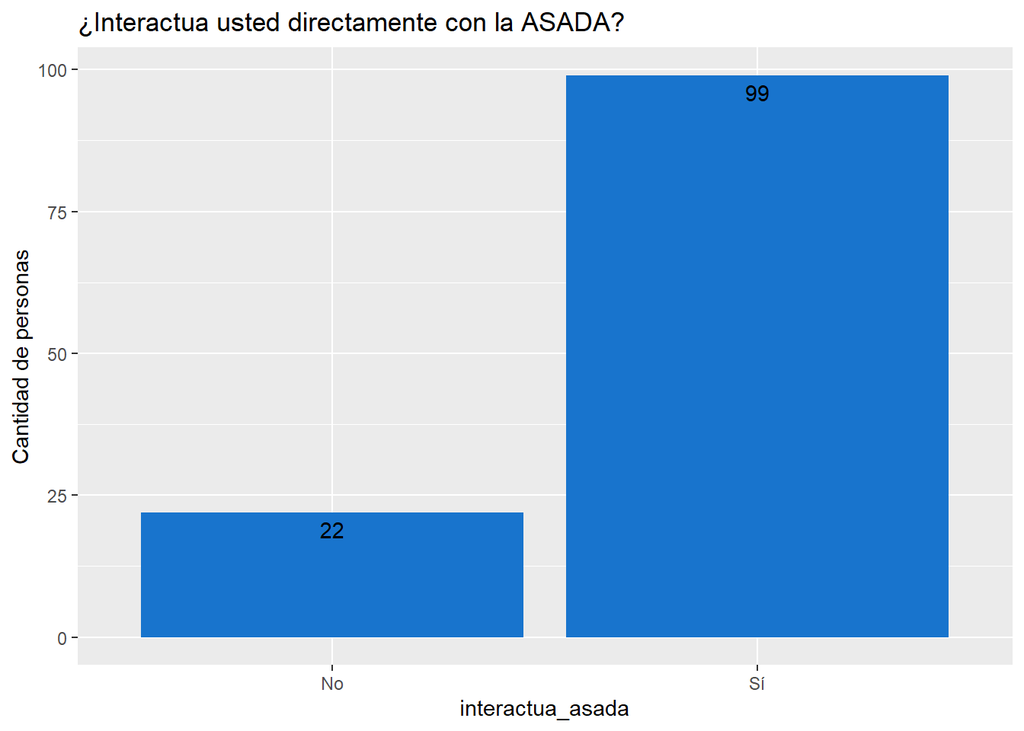

Como era esperable, al encuestar personas clientes de al ASADA, esta tiene un amplio margen de reconocimiento como organización y de acuerdo con sus funciones. Este nivel de reconocimiento es positivo e importante, pues es una primera fase del vínculo con los públicos que se encuentra prácticamente satisfecha. No es de extrañar, pues en adición a lo que se mencionó anteriormente, la ASADA suple de un servicio absolutamente esencial a toda la comunidad.

En cuanto a los medios de interacción con la ASADA, se encontró lo siguiente:

Graficación

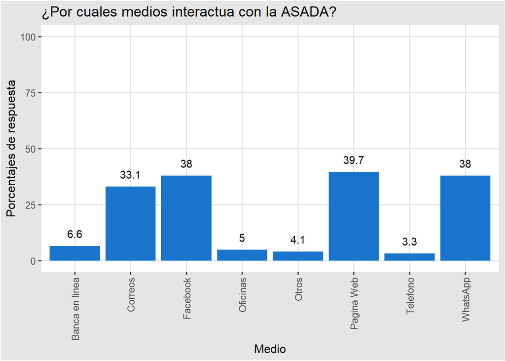

El “internet banking” es un elemento que no se había visualizado ene l diseño original de la encuesta, pero que varias personas encuestadas resaltaron como un medio de interacción con la organización. Asimismo, se observa que las oficinas físicas (en tiempos ordinarios) siguen siendo un elemento importante de interacción de las personas, quienes muchas veces conocen o se referían por nombre, a quienes atienden en las oficinas o quienes dirigen la organización.

Preguntas adicionales sobre la comunicación de la ASADA

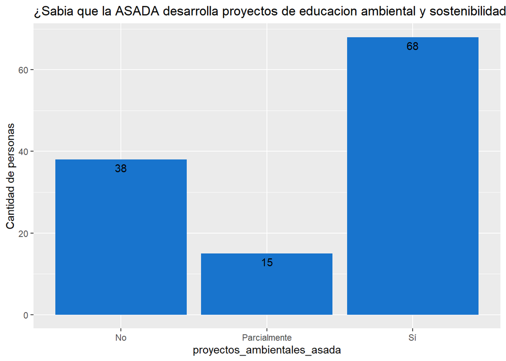

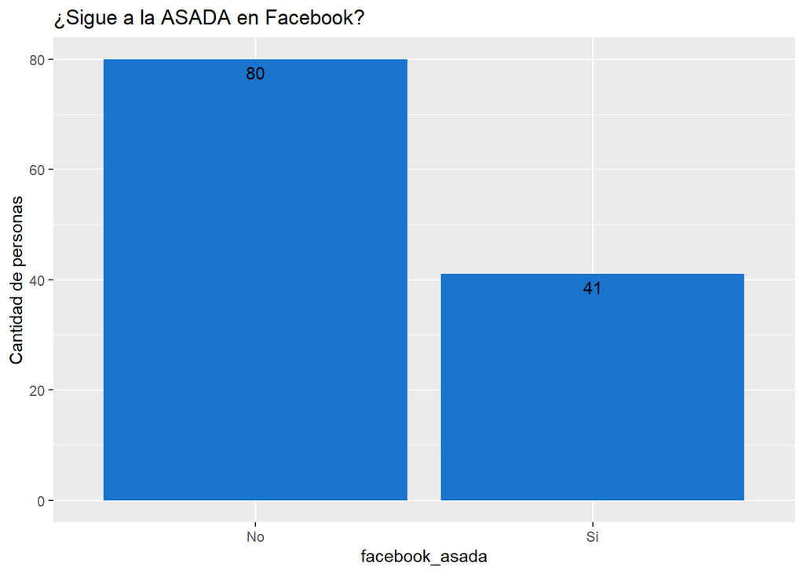

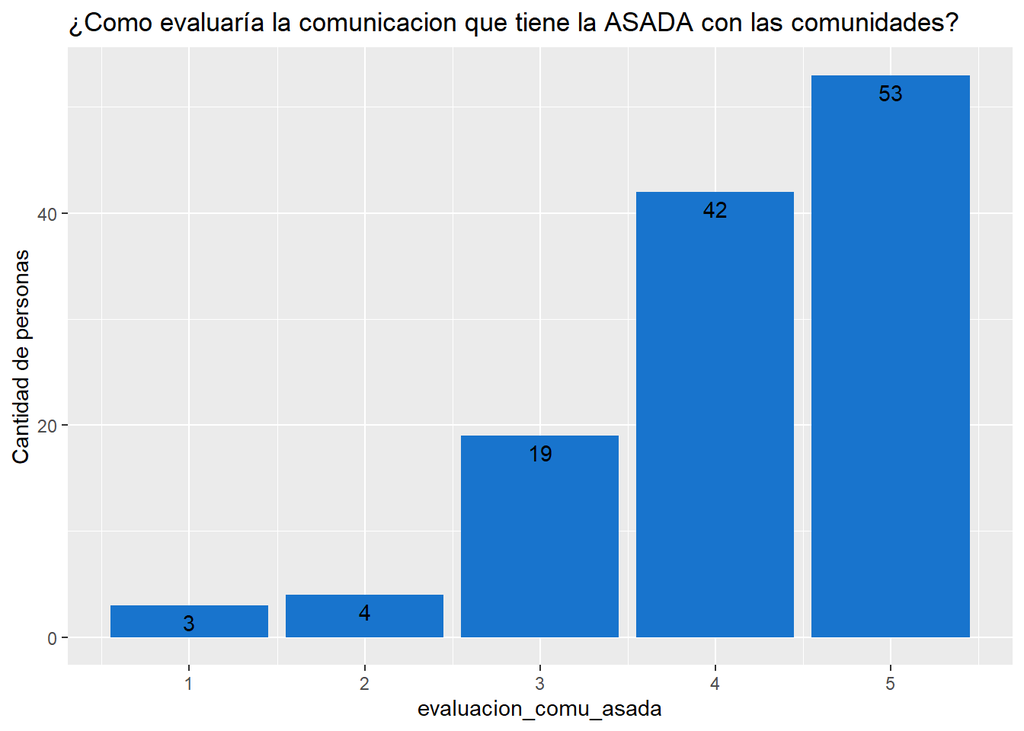

Los proyectos de sostenibilidad y educación ambiental fueron recalcados como un área de posible trabajo por la administración de la ASADA en la reunión original. Y, si bien muchas personas saben que estos proyectos existen, es un porcentaje mucho menor al que reconoce a la ASADA como tal. Adicionalmente, muchas personas pueden conocer la existencia de los proyectos, pero no saber más de ellos o no haberse involucrado. Esta es un área de trabajo importante que puede ser abordada a nivel de estrategia.

También salta que, si bien muchas personas utilizan Facebook para informarse (commo se ha evidenciado anteriormente), no es un porcentaje tan importante el que sigue directamente a la ASADA, por lo que podrían generarse tácticas orientadas a mejorar su alcance. Se recomienda, también, evaluar las métricas de esta página.

En cuanto a la evaluación de la comunicación, se ve que tiene una respuesta muy positiva de la comunidad, por lo que es posible que no haya que reevaluar mucho los mecanismso actuales de comunicación en cuanto a su impacto, sino únicamente en cuanto a otros aspectos como la practicidad y el costo. También, un aspecto importante que debe ser evaluado es el del contenido, como se desarrollará más adelante.

La última pregunta, también abierta, se graficará mediante un segundo “WordCluod”. Esta versa sobre cómo la ASADA podría mejorar su comunicación con las comunidades.

```
##                      word freq
## más                   más   35
## información   información   21
## comunicación comunicación   20
## personas         personas   12
## para                 para   12
## comunidad       comunidad   12
## hay                   hay   10
## mejorar           mejorar    9
## whatsapp         whatsapp    9
## nada                 nada    9
```

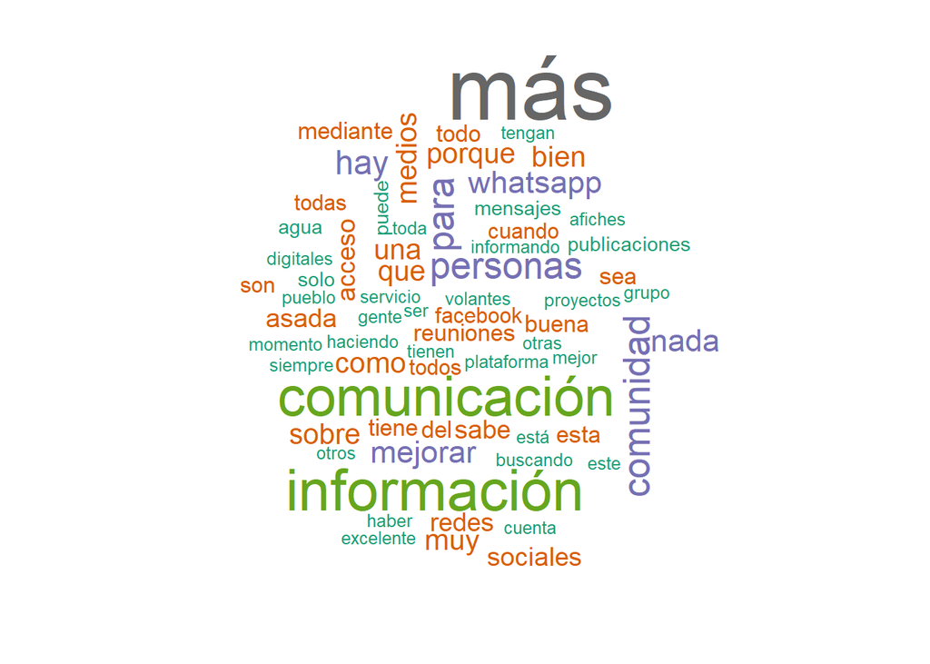

Muchas personas mencionan que la comunicación de la ASADA es buena, pero al consultarles sobre puntos de mejora, mencionan más información o más comunicación. De la interpretación de las preguntas anteriores se desprende que la ampliación de contenido, enfocada en aspectos como la educación ambiental y la sostenibilidad del recurso hídrico, puede ser uno de los focos principales de una eventual estrategia de apoyo por parte del TC-550.

# Cruces de variables

Por último, para este reporte se realizarán algunos cruces de variables para entender mejor cómo las difernetes personas interactúan con sus entornos comunicativos en Bijagua.

La primera versa sobre el uso de medios para informarse sobre el acontecer en Bijagua, según la edad de las personas.

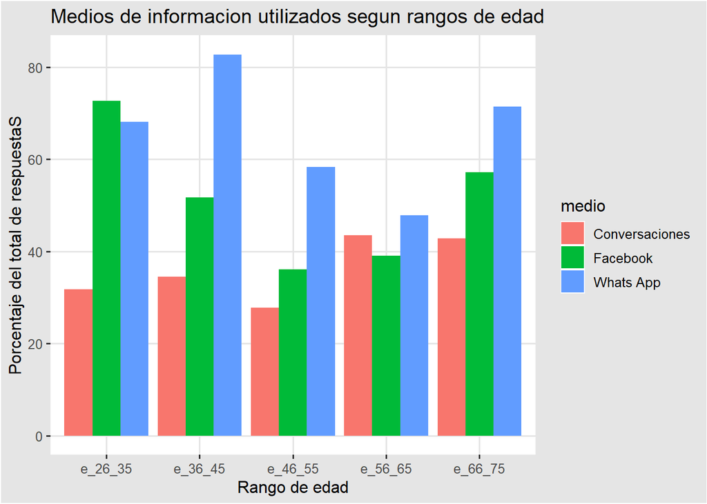

El análisis anterior se generó a partir del “porcentaje de la población del grupo etario que respondió”. Es decir, la composición de la muestra no afectaría de manera importante esta gráfica, sino que se minimiza su impacto para poder visualizar las diferencias en el consumo de información de las diferentes poblaciones.

El segundo cruce de información que se realiza es más bien para determinar si hay cambios entre los medios que utilizan las personas que sí conocen los proyectos ambientales de la ASADA para informarse y los que no.

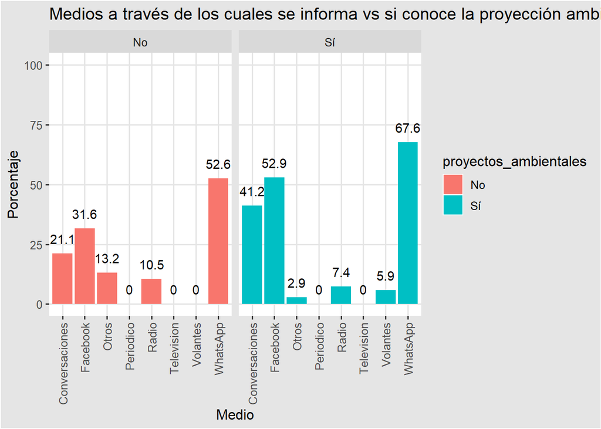

De este gráfico, se desprenden dos aspectos importantes: El primero es que las personas que tienden a informarse por más de un medio, son más propensas a conocer los proyectos de sostenibilidad y educación ambiental de la organización, y la segunda, es que proporcionalmente quienes utilizan más las redes sociales también reciben más información de la organización.

Al igual que la gráfica anterior, esta fue construida partiendo de los porcentajes de respuesta, para minimizar el impacto del tamaño de la muestra en los resultados.

El tercer cruce, parte del mismo principio de revisar el porcentaje dentro de cada grupo, pero esta vez que respondieron que sí conocen los proyectos ambientales de la ASADA, en función de los grupos etarios.

Es decir, se grafica qué porcentaje de cada grupo etario sí conoce estos proyectos.

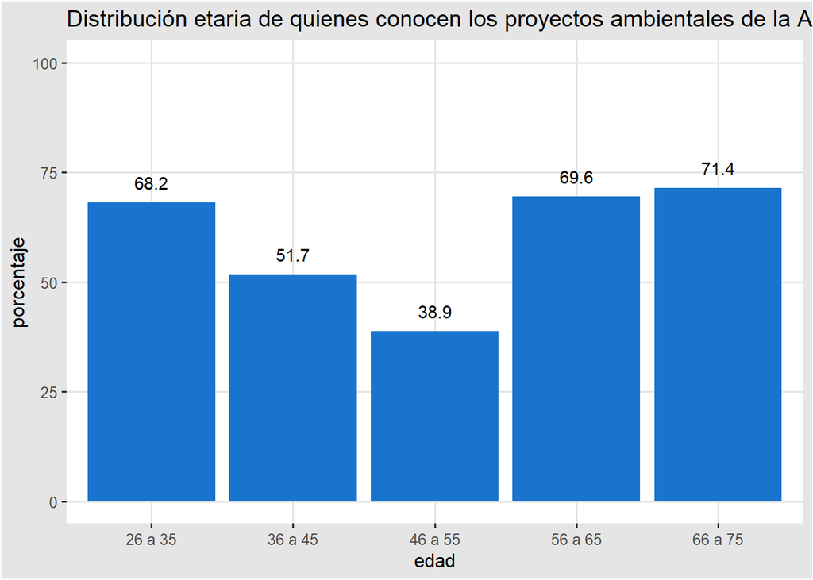

Para continuar el análisis etario, se propone graficar ahora los principales medios de información por rango de edad.

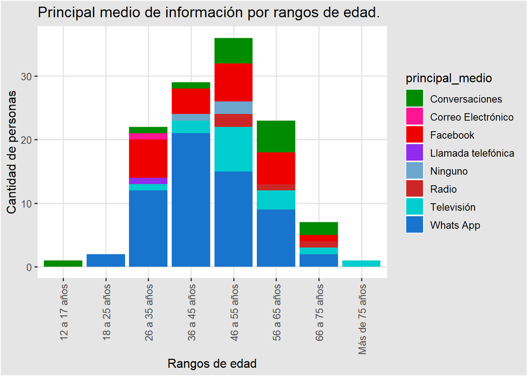

Este mismo análisis, que segrega los medios de información según una característica demográfica específica, se realizará por género y por barrio.

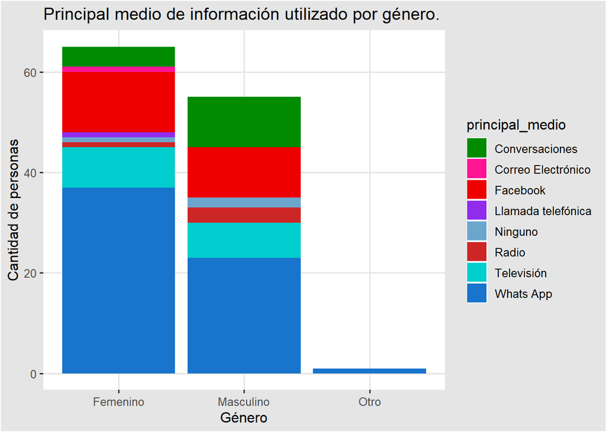

Este análisis no muestra ninguna diferencia significativa entre medios de información por género, por lo que se recomienda no utilizar diferenciación de medios para segregar la comunicación por género.

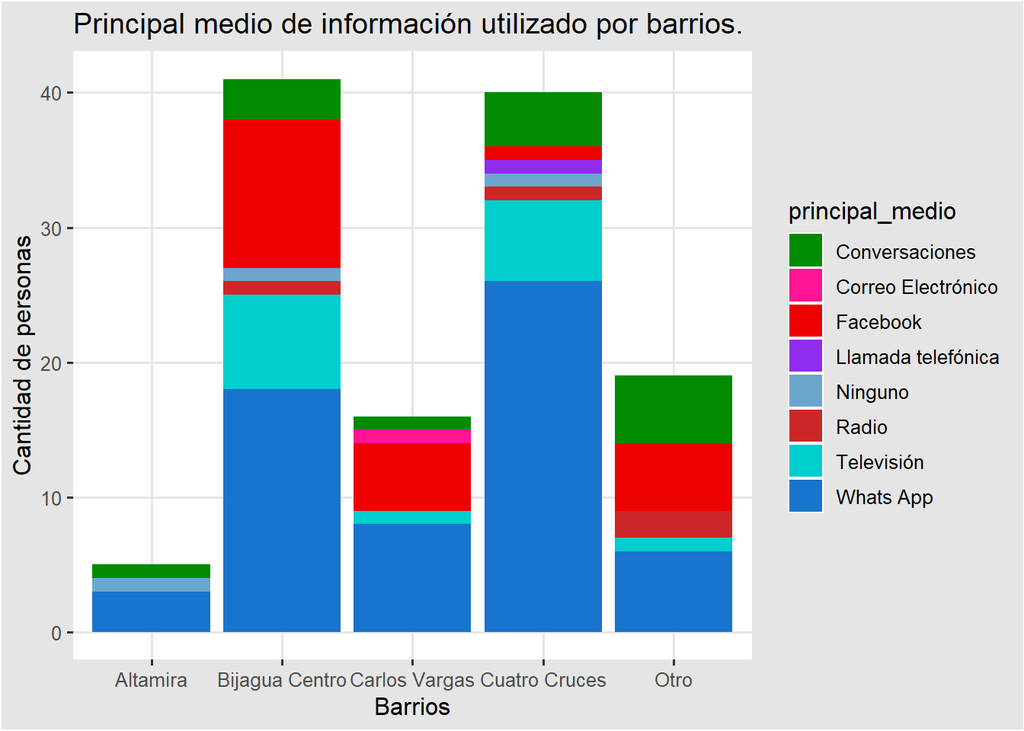

En este caso, sí se encuentran algunas diferencias significativas, por lo que se debe tener esta visualización en cuenta para el planteamiento de la estrategia.

Ahora, el se realizará la misma segregación por edad, género y barrio, pero ahora en función del tipo de material que prefieren para infrmarse.

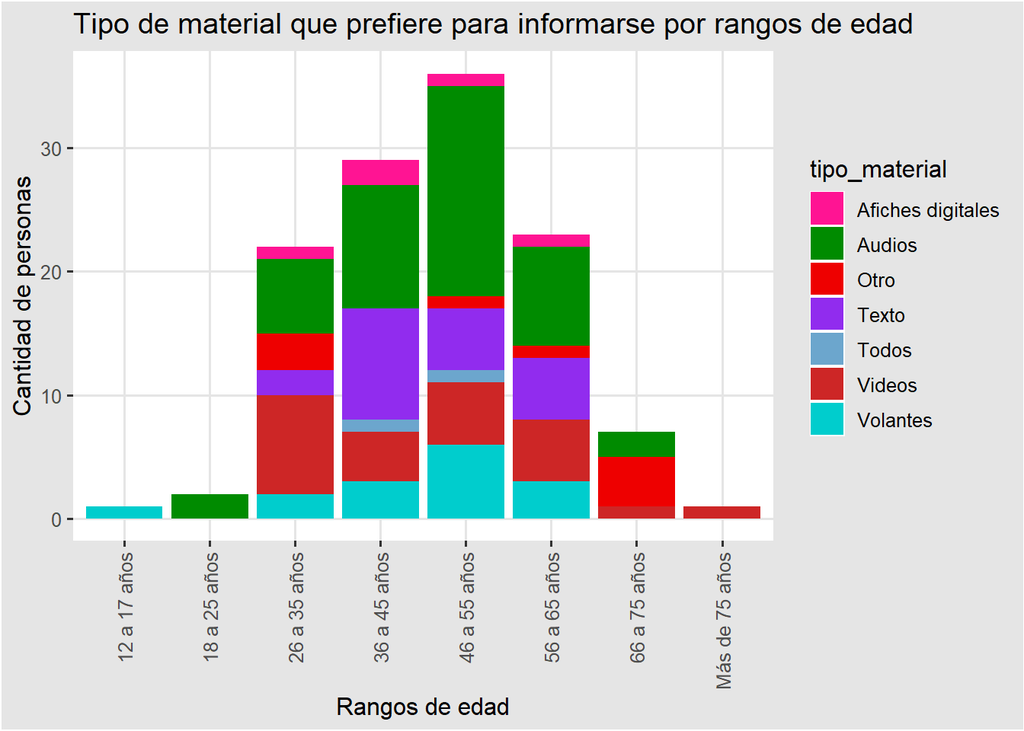

Se evidencia que sí hay diferencia entre los rangos etarios, que debe tomarse en cuenta a la hora de segregar la comunicación.

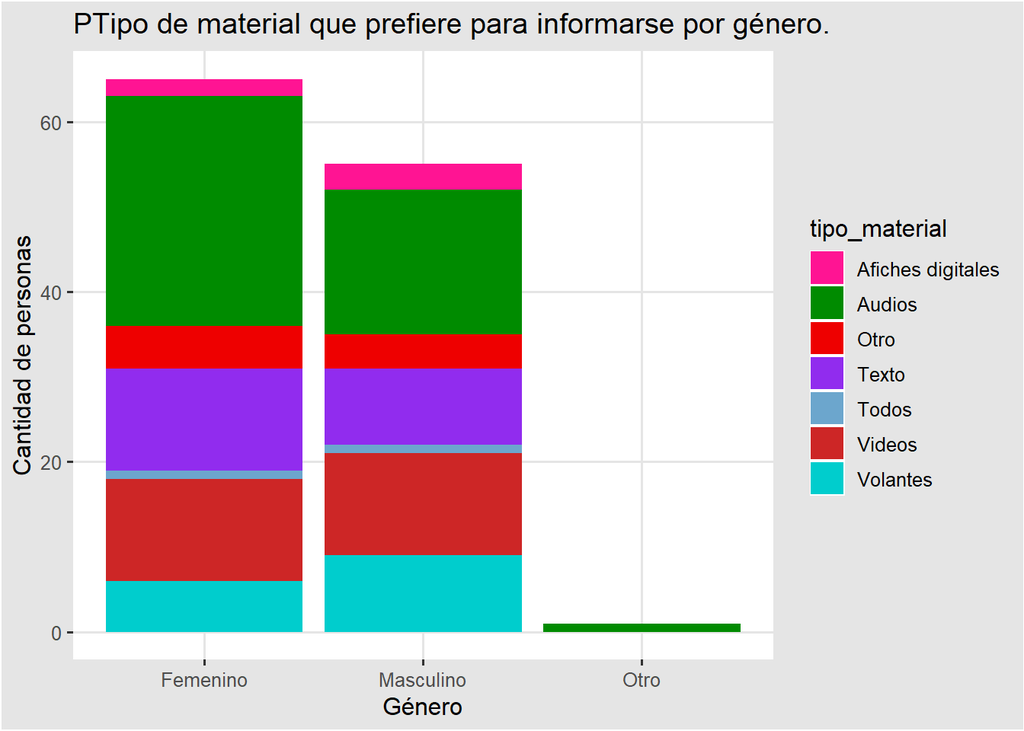

Si bien la diferencia no es evidentemente significativa, sí existen algunos ligeros cambios que pueden tomarse en cuenta.

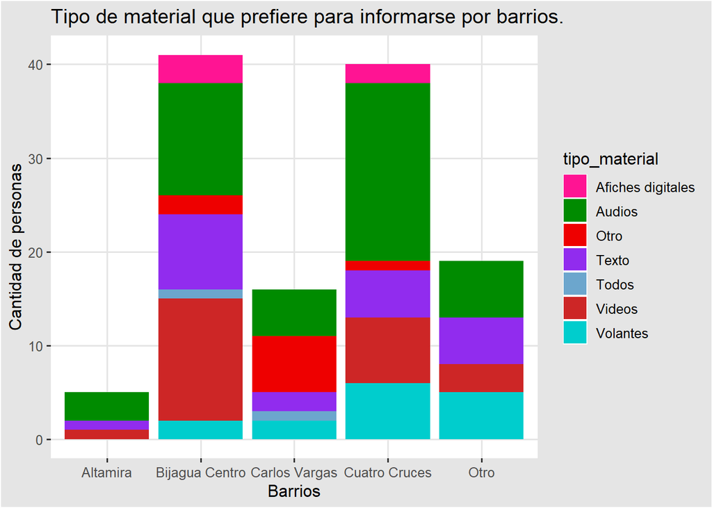

Nuevamente, se evidencian diferencias importantes entre los diversos barrios. Esto debe tomarse en cuenta para segregar la comunicación.

El último cruce que se va a realizar en este informe preeliminar es sobre Facebook. Se segregarán las respuestas que indicaron Facebook como un medio de recepción de información y se graficará, a partir de estas, si siguen a la ASADA en Facebook.

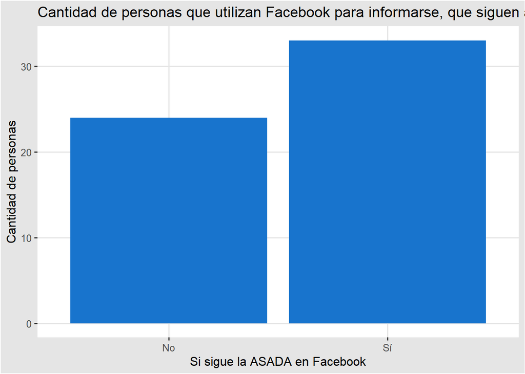

Si bien el resultado es positivo, en el sentido de que la mayoría de personas sí siguen a la ASADA, se identificca una oportunidad de mejora para llegar a ese porcentaje de la población que no está recibiendo la información por este mdio.

# Conclusiones